# ProsperLoan Data Analysis

### The structure of the dataset

> Unwrangled,the ProsperLoan dataset has 113,937 rows and 81 columns. The information in every row corresponds to a loan that was issued by Prosper MarketPlace, and each column contains distinct information about the loan, such as loan terms, credit scores, borrowers' personal information etc. See a brief summary of the columns in the dataset below: Loan-related columns: LoanOriginalAmount, interest rate, Loan term, etc. Borrower-related columns: income range, employment status, occupation, state etc. Loan performance columns: current loan status, loan duration, delinquency status, etc. Credit score columns: borrower's credit score, creditscore range etc. Other columns: listing category, lender yield, etc. Ultimately, the dataset is a structured dataset, with every of the 113,937 rows representing a single loan and each column representing a particular feature of that loan.

### The main feature(s) of interest in this dataset

> Loan amount: the amount of money loaned to the borrower. Interest rate: the annual interest rate charged on the granted loan . Term length: the length of time/period the borrower is given to repay the loan. Loan status: the current status of the loan (e.g., current, charged off, default, etc.). Borrower's credit score: the credit score of the borrower at the time the loan was issued. Income range: of the borrower. Occupation: the occupation of the borrower.

### The features in the dataset that will help support my investigation into my feature(s) of interest

> Credit score ranges: this feature may be helpful for identifying relationships between credit score and loan performance. Employment status: this feature may be useful for exploring the relationship between employment status and loan performance as well as how this relates with occupation type

## Univariate Exploration

```python
import matplotlib.pyplot as plt
import seaborn as sns
```

## Question :What is the distribution of loan amounts?

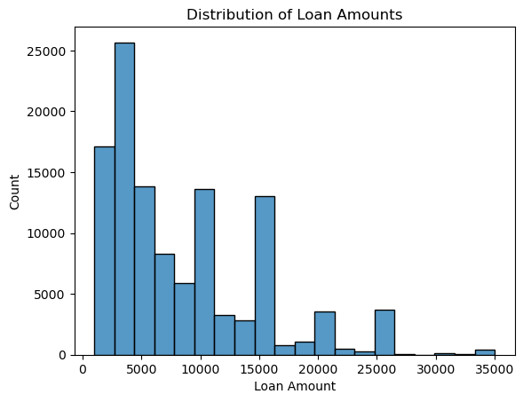

```python
sns.histplot(data=df, x='LoanOriginalAmount', bins=20)
plt.title('Distribution of Loan Amounts')
plt.xlabel('Loan Amount')
plt.ylabel('Count')
plt.show()
```

## Question:What is the Frequency of borrower employment status?

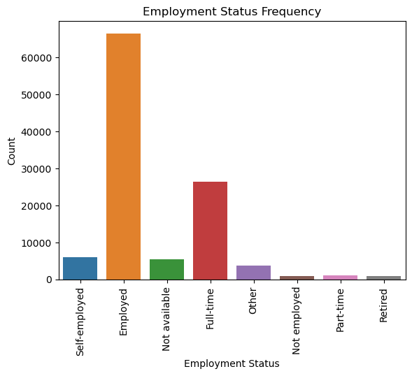

```python
sns.countplot(data=df, x='EmploymentStatus'), plt.xticks(rotation=90)
plt.title('Employment Status Frequency')
plt.xlabel('Employment Status')
plt.ylabel('Count')
plt.show()
```

## Question: What is the distribution of loan terms?

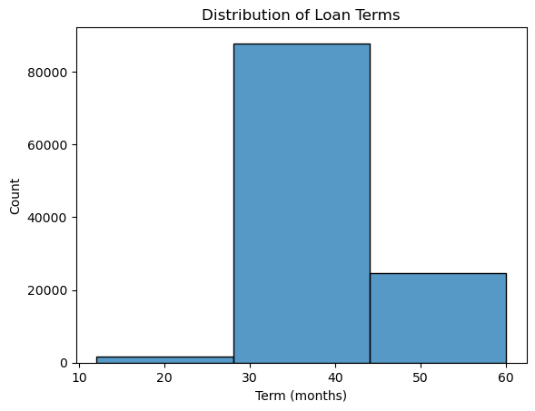

```python
sns.histplot(data=df, x='Term', bins=3)
plt.title('Distribution of Loan Terms')
plt.xlabel('Term (months)')
plt.ylabel('Count')
plt.show()
```